# Module_9: Multiple Linear Regression

Harry Smith and Caroline Ledbetter

6/29/2018

**Introduction To Multiple Regression** Recall that simple linear regression involves two variables: one independent and one dependent variable. Multiple linear regression is an extension of simple linear regression, which involves one dependent (or response) variable and two or more independent (primary factors(s) of interest, confounders, or effect modifiers) variables.

Multiple linear regression analyses can be done in R by the same procedure that was used for simple linear regression, lm(). The general syntax for the procedure is similar to the previous lab - we are simply adding more terms to the right side of the model. The syntax for specifying are dependent and independent variables is similar except for specifying “interaction” terms and “categorical” variables. These differences will be discussed in the subsequent sections.

**Background and The Problem** In demonstrating multiple linear regression we will use a modified dataset (from Neter, Kutner, Nachtsheim, and Wasserman) from an ecological study on length of stay in a hospital and its relationship to other hospital-specific variables. For example, length of a hospital stay might vary by region of the country, by the average age of patients in hospitals (older patients generally are sicker and stay longer), by whether a hospital is associated with a medical school (seems that more resources are available to those with a school), and by how likely a patient is to acquire a nosocomial infection (infection acquired while in the hospital). We might also think that geographic region impacts the association between length of stay and medical school affiliation. We’ll show how to test this assumption or conjecture of an interaction (also called “effect modification”) in the context of regression modeling.

Consider the following characteristics that we know about a sample of hospitals in various regions of the country and put into an electronic dataset for evaluation:

- LOS - the average length of stay for patients admitted to a given hospital
- AGE - the average age of patients admitted to a given hospital
- INFRISK - the average estimated probability of acquiring an infection in a given hospital
- MEDSCHL - indicator of whether hospital is affiliated with a medical school or not
- REGION - an indicator representing the region of the country in which the hospital resides, where (1=NE, 2=NC, 3=S, 4=W).

We’ll use this dataset to determine the important factors, which influence the average length of stays among hospitals with these various characteristics.

**Dummy Variables** A set of “dummy variables” (with one set per categorical variable in the dataset) is an *alternative representation* of a single categorical variable. The collection consists of one less dummy variable than the total levels or choices identified in the categorical response variable. Indicator or binary response variables are each coded with only 1 or 0, depending on whether or not a discrete level is observed. For example, consider the trivial, discrete variable gender, which can take on one of two categories, male or female. We can represent this categorical response with a single binary indicator variable, say “sex_male”, which is set to 1 wherever the current subject is male, or set to 0 whenever the current individual is female.

**Note:** we need only 1 (2-1=1) dummy variable for a categorical variable with 2 levels.

For categorical variables with more than two categories, say **c** categories or choices, **c-1** dummy variables are needed to capture the information provided in the single, **c** level, discrete (or categorical) variable. (While it seems inefficient to introduce **c-1** indicator variables for a single c-level discrete variable, this manipulation allows the software to acquire **c-1** estimates, which represent the **c-1** differences. Each of these are from a pre-selected common category (reference category) rather than one summary estimate representing the average change over all c categories, simultaneously. In practice, one of the **c** categories is set aside or chosen to be the reference group. Whenever an individual or study subject is in this reference group, then all the **c-1** dummy variables are set to 0. Whenever a subject or individual falls into a non-reference category, a pre-selected dummy variable (any one chosen to represent this category) is set to the value one and the remaining dummy variables are set to zero.

**Critical Note:** While the R function, lm() will build all the dummy variables for each categorical variable in the model, the syntax of lm() requires us to redefine all categorical variables. That is, we must redefine each of the categorical variables declared in the model to be a “factor” variable and then lm() can generate the correct set of dummy variables for each categorical variable in the model.

R provides a simple way to create a “factor” variable from a categorical variable. The function factor() creates a new variable or replaces an existing variable in a dataset with a define “factor” array. For example, the variable REGION in the dataset above has four categories: 1=northeast, 2=northcentral, 3=south, and 4=west. To convert this variable to a factor variable with the same name, we would use the following code: **note:** you can’t run these code sections yet, as we have not loaded a dataset. They are just examples.

```
apc1$region <- factor(apc1$region,
levels = c(1,2,3,4),
labels = c("northeast", "northcentral", "south", "west"))
```

or to add a new variable to the dataset use:

```
apc1$newregion <- factor(apc1$region,
levels = c(1,2,3,4),
labels = c("northeast", "northcentral", "south", "west"))
```

```
apc1$newregion <- factor(apc1$region, levels = c(2,1,3,4), labels = c("_ref", "_NE", "_S", "_W"))
```

or:

```
apc1$newregion <- relevel(apc1$newregion, ref = "northcentral")
```

**Coding Interactions (or Effect Modification)** An interaction term in the model measures, for each level of an observed variable, the quantitative impact that the various levels of this variable (regressor, covariate, parameter or nuisance variable) has on the relationship of another variable of greater interest (also known as the hypothesized or primary effect of interest) with the outcome variable of interest. For convenience, we say we introduced “main effects” into a model by just including the names of the variables in the lm() function. Likewise, we say we have a “one-way interaction” when we include the crossed-term (specified as var1*var2) of the two variables into the lm() function. In general, we can specify higher levels of interaction involving additional main effects, by including all the main effects and all lower level interaction terms. In a simple case, including an interaction term with both the main effects is, for example, coded as:

```
lm(outcome ~ var1 + var2 + var1*var2)
```

In epidemiology, the quantitative estimates calculated for the term var1*var2 in the multiple regression model is called ‘effect modification’. Consequently, the interaction is an adjustment to the estimated impact of the main effects when the two covariates do not independently impact the change in the mean outcome value.

**Example Multiple Regression analysis with Coding and Output - Reading in and Preparing the Dataset:**

```r
##  Here we are reading in the apc1 dataset.
apc1 <- read.table("/Users/harry/Documents/BIOS6605/Summer_2018/data/APC1.DAT")

## Verify that the dataset read in correctly by printing the first 6 rows.
head(apc1)
```

```
##   V1    V2   V3  V4   V5    V6  V7 V8 V9 V10 V11 V12
## 1  1  7.13 55.7 4.1  9.0  39.6 279  2  4 207 241  60
## 2  2  8.82 58.2 1.6  3.8  51.7  80  2  2  51  52  40
## 3  3  8.34 56.9 2.7  8.1  74.0 107  2  3  82  54  20
## 4  4  8.95 53.7 5.6 18.9 122.8 147  2  4  53 148  40
## 5  5 11.20 56.5 5.7 34.5  88.9 180  2  1 134 151  40
## 6  6  9.76 50.9 5.1 21.9  97.0 150  2  2 147 106  40
```

```r
## Provide column headings for the 6 columns that we are interested in looking.
names(apc1)[1] <- "id"
names(apc1)[2] <- "los"
names(apc1)[3] <- "age"
names(apc1)[4] <- "infrisk"
names(apc1)[8] <- "medschl"
names(apc1)[9] <- "region"

## Verify that the column headings were named correctly.
head(apc1)
```

```
##   id   los  age infrisk   V5    V6  V7 medschl region V10 V11 V12
## 1  1  7.13 55.7     4.1  9.0  39.6 279       2      4 207 241  60
## 2  2  8.82 58.2     1.6  3.8  51.7  80       2      2  51  52  40
## 3  3  8.34 56.9     2.7  8.1  74.0 107       2      3  82  54  20
## 4  4  8.95 53.7     5.6 18.9 122.8 147       2      4  53 148  40
## 5  5 11.20 56.5     5.7 34.5  88.9 180       2      1 134 151  40
## 6  6  9.76 50.9     5.1 21.9  97.0 150       2      2 147 106  40
```

```r
## Delete the columns from the dataset that are not needed for the analysis.
apc1$V5 = apc1$V6 = apc1$V7 = apc1$V10 = apc1$V11 = apc1$V12 = NULL

## Create dummy codes for the medschl and region variables.
apc1$mdschl <- factor(apc1$medschl,
                      levels = c(1,2),
                      labels = c("y", "n"))
apc1$newregion <- factor(apc1$region, levels = c(1,2,3,4),
                         labels = c("northeast", "northcentral",
                                    "south", "west"))

## Print the first 6 rows of the dataset to make sure that the dummy
#  coding worked properly.
head(apc1)
```

```
##   id   los  age infrisk medschl region mdschl    newregion
## 1  1  7.13 55.7     4.1       2      4      n         west
## 2  2  8.82 58.2     1.6       2      2      n northcentral
## 3  3  8.34 56.9     2.7       2      3      n        south
## 4  4  8.95 53.7     5.6       2      4      n         west
## 5  5 11.20 56.5     5.7       2      1      n    northeast
## 6  6  9.76 50.9     5.1       2      2      n northcentral
```

Our first step will be to look at scatterplots of the dependent variable, length of stay, with respect to the independent variables.

**Plots of Length of Stay vs. Age, Infection Risk, Medical School Affiliation, and Region**

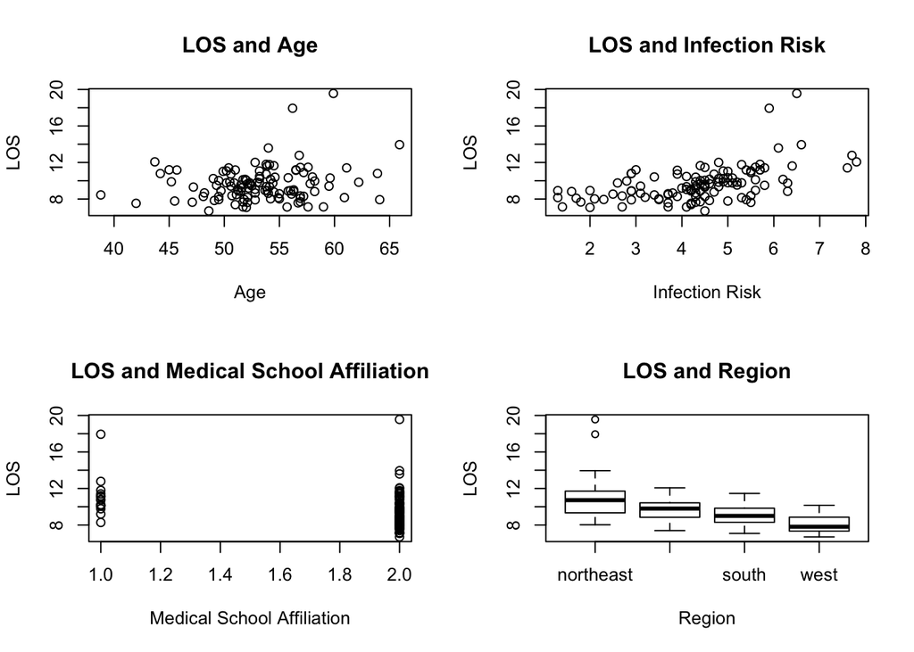

```r
## save default plotting paramters

## generate plots
par(mfrow=c(2,2))
plot(apc1$age, apc1$los, ylab="LOS", xlab="Age",
     main= "LOS and Age")
plot(apc1$infrisk, apc1$los, ylab="LOS", xlab="Infection Risk",
     main= "LOS and Infection Risk")
plot(apc1$medschl, apc1$los, ylab="LOS", xlab="Medical School Affiliation",
     main= "LOS and Medical School Affiliation")
plot(apc1$newregion, apc1$los, ylab="LOS", xlab="Region",
     main= "LOS and Region")
```

**Note:** To put graphs in a panel presentation as above, you can save the plots in R to a folder/file and then use the MS/Word Insert / (Table, Pictures) and then modify the size of the plots to fit your presentation.

What relationships do you observe in each plot? Does there appear to be a linear relationship between length of hospital stay and age? and infection risk? Does the mean length of stay appear to differ between hospitals that affiliated with a medical school and ones that are not? among regions? Which variables do you think will result in non-zero regression estimates (los vs. age, infection risk) or non-zero mean differences (los across levels of medical school affiliation, region)?

Does the distribution of length of stay appear to follow a Normal distribution for specific values of age? for infection risk? for the categories of medical school affiliation? for geographic region? …

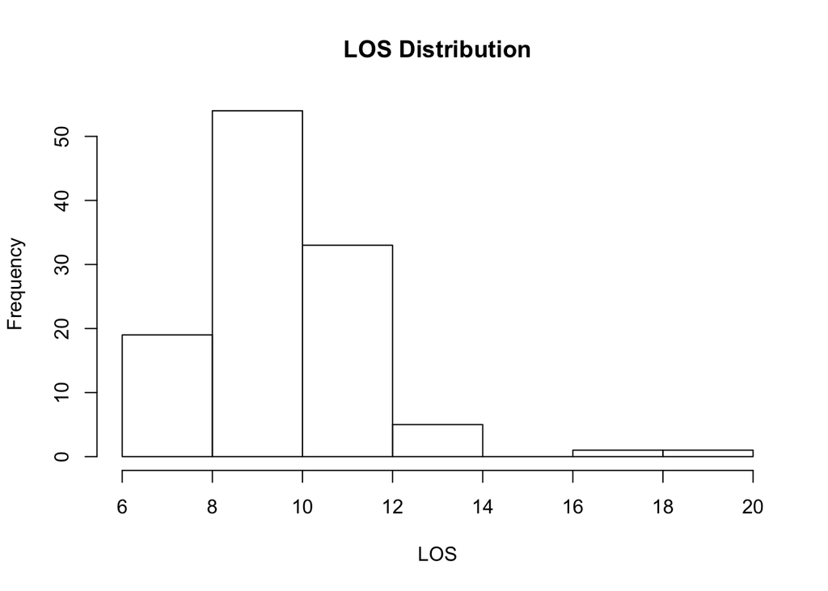

```r
hist(apc1$los, xlab="LOS", main= "LOS Distribution")
```

Given the slight right skewness we see in the length of stay variable, it might be better to transform it by taking the natural log and then proceed with the analysis. We would do this using:

```r
apc1$loglos <- log(apc1$los)
```

As a descriptive tool, let’s compute the correlations between “apc1$loglos” (the natural log of length of stay) and age and infection risk. Correlation isn’t appropriate for looking at mean differences across affiliation categories or across regions. We’ll use the describeBy() function from the psych package to get descriptive statistics for those two variables.

```r
cor(apc1$age, apc1$loglos)
```

```
## [1] 0.170958
```

```r
cor(apc1$infrisk, apc1$loglos)
```

```
## [1] 0.5495131
```

Now let’s take a look at “loglos” for the categorical independent variables …

```r
library(psych)
describeBy(apc1$loglos, apc1$medschl)
```

```
##
##  Descriptive statistics by group
## group: 1
##    vars  n mean   sd median trimmed  mad  min  max range skew kurtosis
## X1    1 17 2.38 0.16   2.37    2.37 0.09 2.11 2.89  0.77 1.44     2.93
##      se
## X1 0.04
## --------------------------------------------------------
## group: 2
##    vars  n mean   sd median trimmed  mad min  max range skew kurtosis   se
## X1    1 96 2.23 0.17    2.2    2.22 0.16 1.9 2.97  1.07 0.98     2.49 0.02
```

```r
describeBy(apc1$loglos, apc1$region)
```

```
##
##  Descriptive statistics by group
## group: 1
##    vars  n mean   sd median trimmed  mad  min  max range skew kurtosis
## X1    1 28 2.38 0.21   2.37    2.36 0.18 2.08 2.97  0.89 0.99     0.79
##      se
## X1 0.04
## --------------------------------------------------------
## group: 2
##    vars  n mean   sd median trimmed  mad min  max range  skew kurtosis
## X1    1 32 2.26 0.13   2.28    2.27 0.14   2 2.49  0.49 -0.31    -0.76
##      se
## X1 0.02
## --------------------------------------------------------
## group: 3
##    vars  n mean   sd median trimmed  mad  min  max range skew kurtosis
## X1    1 37 2.21 0.13    2.2    2.21 0.13 1.96 2.44  0.48 0.11    -0.89
##      se
## X1 0.02
## --------------------------------------------------------
## group: 4
##    vars  n mean   sd median trimmed  mad min  max range skew kurtosis   se
## X1    1 16 2.09 0.12   2.06    2.08 0.13 1.9 2.32  0.42  0.4    -1.05 0.03
```

Are there differences in length of stay associated with affiliation and region? Let’s say, now, that we think the effect of medical school affiliation on average length of stay might vary across the regions. How could we visually inspect that hypothesis before proceeding with the regression analysis?

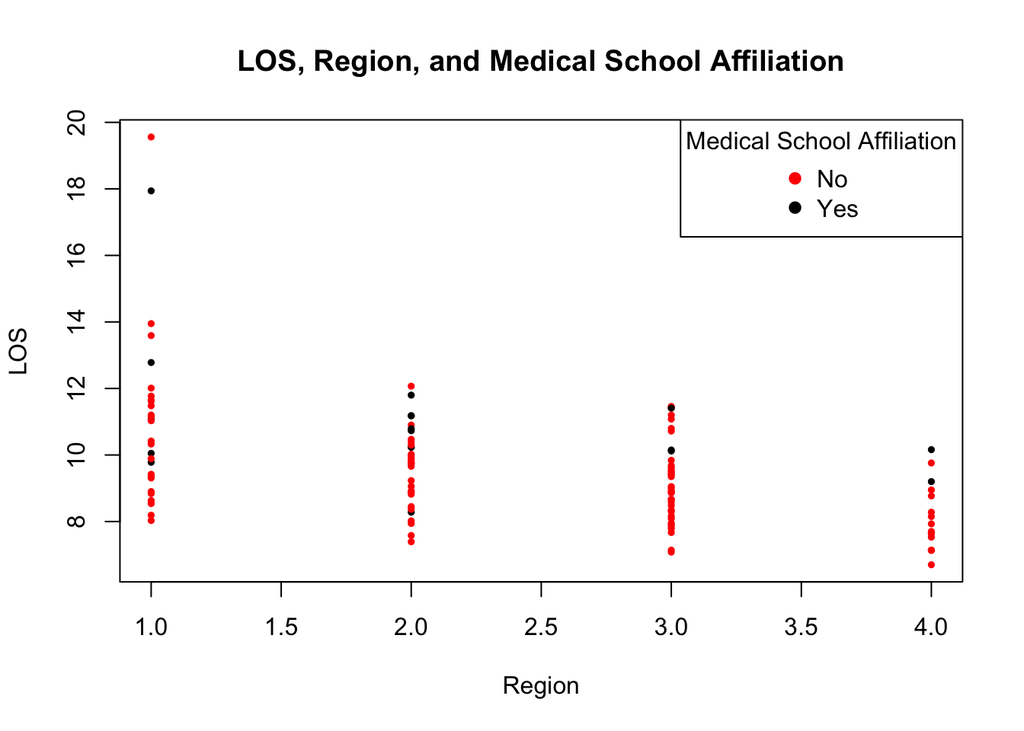

```r
plot(apc1$region, apc1$los,
     ylab="LOS", xlab="Region",
     main= "LOS, Region, and Medical School Affiliation",
     pch=19,cex=0.5, col=(apc1$medschl))

legend("topright", legend = c("No", "Yes"),
       pch=c(19, 19), col = c("red", "black"),
       title="Medical School Affiliation")
```

Do you think that medical school affiliation modifies the effect of geographical region on log(length of stay) (or vice versa)? Why or why not?

Let’s see now how we can fit a model that includes the interaction of interest: medical school affiliation and region. We’ll need to fit a model that includes all of the building blocks – we call these main effects – in addition to the interaction terms.

We’ll start with all of the variables and the hypothesized interaction in the model. We need to assess the fit of this model before proceeding to hypothesis testing about the parameters (slope coefficients).

**Fitting a Model with Main Effects and Interactions**

```r
## Recode medschl
apc1$medschl[apc1$medschl == 1] = 1
apc1$medschl[apc1$medschl == 2] = 0
## format as factor
apc1$medschl <- factor(apc1$medschl,
                       levels = c(0,1),
                       labels = c("No", "Yes"))
## recode region
apc1$region[apc1$region == 4] = 0
apc1$region[apc1$region == 3] = 3
apc1$region[apc1$region == 2] = 2
apc1$region[apc1$region == 1] = 1
## format as factor
apc1$region <- factor(apc1$region,
                      levels = c(0,1,2,3),
                      labels = c("W", "NE", "NC", "S"))
## fit multiple linear regression model, which includes interaction between medschool and region
model1 <- lm(loglos ~ age + infrisk + medschl + region + medschl*region,
             data=apc1)
## get model summary and estimate confidence intervals
summary(model1)
```

```
##
## Call:
## lm(formula = loglos ~ age + infrisk + medschl + region + medschl *
##     region, data = apc1)
##
## Residuals:
##      Min       1Q   Median       3Q      Max
## -0.29404 -0.06549 -0.00934  0.05586  0.46165
##
## Coefficients:
##                      Estimate Std. Error t value Pr(>|t|)
## (Intercept)          1.401266   0.150013   9.341 2.16e-15 ***
## age                  0.007265   0.002654   2.738  0.00729 **
## infrisk              0.061793   0.009232   6.693 1.17e-09 ***
## medschlYes           0.215359   0.091316   2.358  0.02024 *
## regionNE             0.273747   0.041111   6.659 1.38e-09 ***
## regionNC             0.187583   0.040411   4.642 1.02e-05 ***
## regionS              0.172525   0.038827   4.443 2.24e-05 ***
## medschlYes:regionNE -0.144034   0.109427  -1.316  0.19101
## medschlYes:regionNC -0.096081   0.105185  -0.913  0.36314
## medschlYes:regionS  -0.169111   0.118688  -1.425  0.15723
## ---
## Signif. codes:  0 '***' 0.001 '**' 0.01 '*' 0.05 '.' 0.1 ' ' 1
##
## Residual standard error: 0.1208 on 103 degrees of freedom
## Multiple R-squared:  0.5764, Adjusted R-squared:  0.5393
## F-statistic: 15.57 on 9 and 103 DF,  p-value: 9.224e-16
```

```r
confint(model1)
```

```
##                            2.5 %     97.5 %
## (Intercept)          1.103749578 1.69878143
## age                  0.002001839 0.01252817
## infrisk              0.043482152 0.08010301
## medschlYes           0.034255528 0.39646297
## regionNE             0.192212740 0.35528080
## regionNC             0.107437722 0.26772730
## regionS              0.095521974 0.24952864
## medschlYes:regionNE -0.361055785 0.07298867
## medschlYes:regionNC -0.304690564 0.11252832
## medschlYes:regionS  -0.404500898 0.06627929
```

Let’s look first at the residuals from this model: the deviations of the observations from their predicted values. These will tell us something about how valid the assumption is of normality of the log(length of stay) variable given the independent variables. The raw residuals tend to have patterns in them that are misleading. We use Studentized (or standardized) residuals instead – the raw residuals divided by their standard deviation. Recall that the residual variance is denoted as $\sigma^2_{y\mid x}$. The standard deviation of the residuals is then the square root of $\sigma^2_{y\mid x}$.

In R, we can get the QQplot for studentized residuals by using the qqPlot() function from the car package. To get the distribution of studentized residuals histogram we use the studres() function in the MASS package.

```r
par(mfrow=c(1,2))
#install.packages(“car”)
library(car)
```

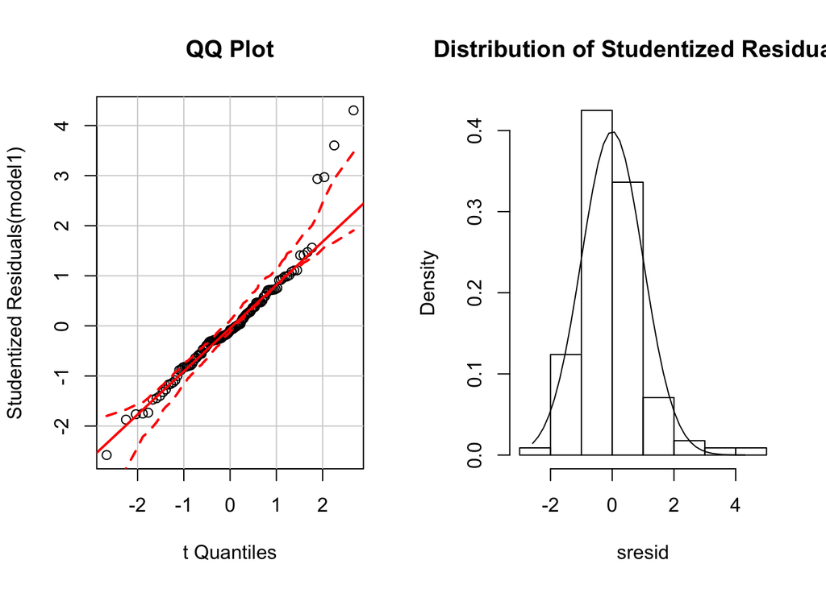

```r
qqPlot(model1, main="QQ Plot")

#install.packages(“MASS”)
library(MASS)
sresid <- studres(model1)
hist(sresid, freq=FALSE, main="Distribution of Studentized Residuals")
xfit<-seq(min(sresid),max(sresid),length=40)
yfit<-dnorm(xfit)
lines(xfit, yfit)
```

The mean of these Studentized residuals is 0 (as expected, no matter what the model), and the standard deviation is 1. From the Normal probability plot it does appear that the residuals are approximately normally distributed. The right skewness we see comes from a few extreme length of stay values that persist even after the log transformation.

We can also look at other plots of the residuals vs. predicted values and the independent variables. If the assumption of homoscedasticity holds, the residuals should have no relation to the independent variables (or to the prediction). In R, we can get this information by using the plot() function.

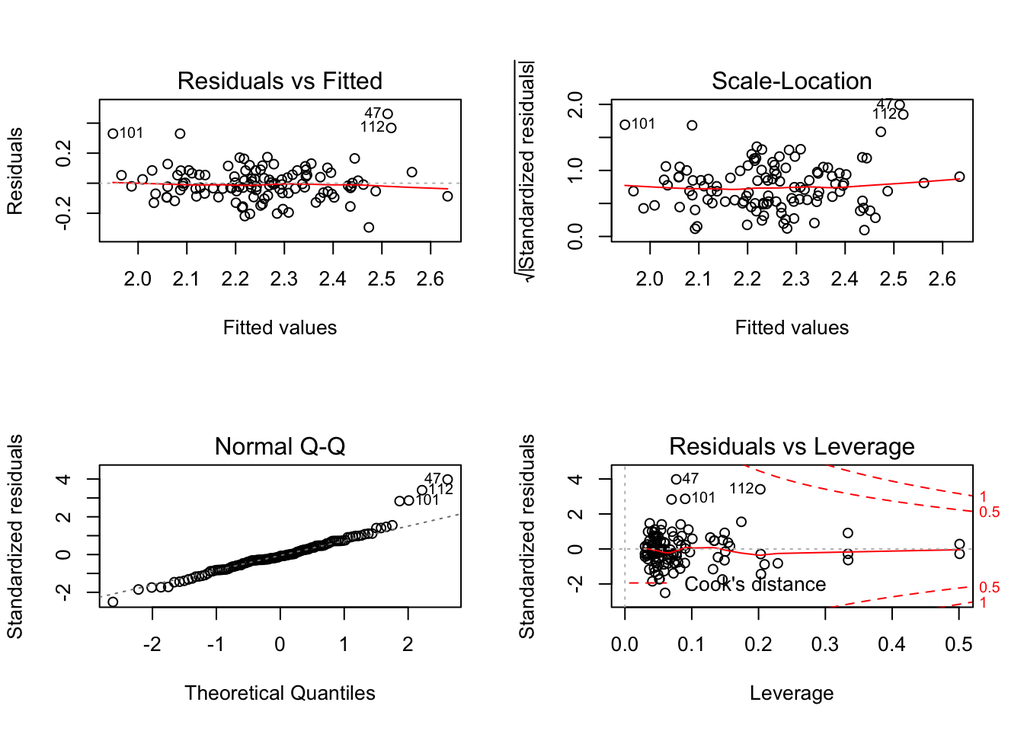

```r
layout(matrix(c(1,2,3,4), 2,2))

plot(model1)
```

**Since there are no discernible patterns of the residuals in these plots we can proceed to looking for influential observations.**

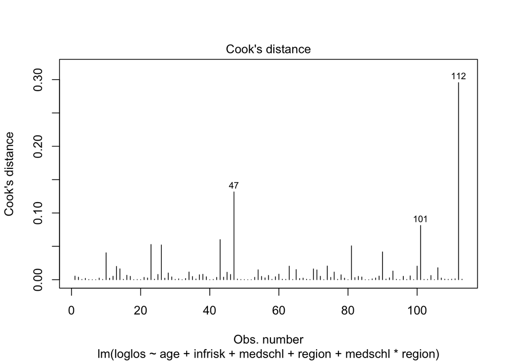

```r
#install.packages(“car”)
library(car)

cutoff <- 4/((nrow(apc1)-length(model1$coefficients)-2))
plot(model1, which=4, cook.levels=cutoff)
```

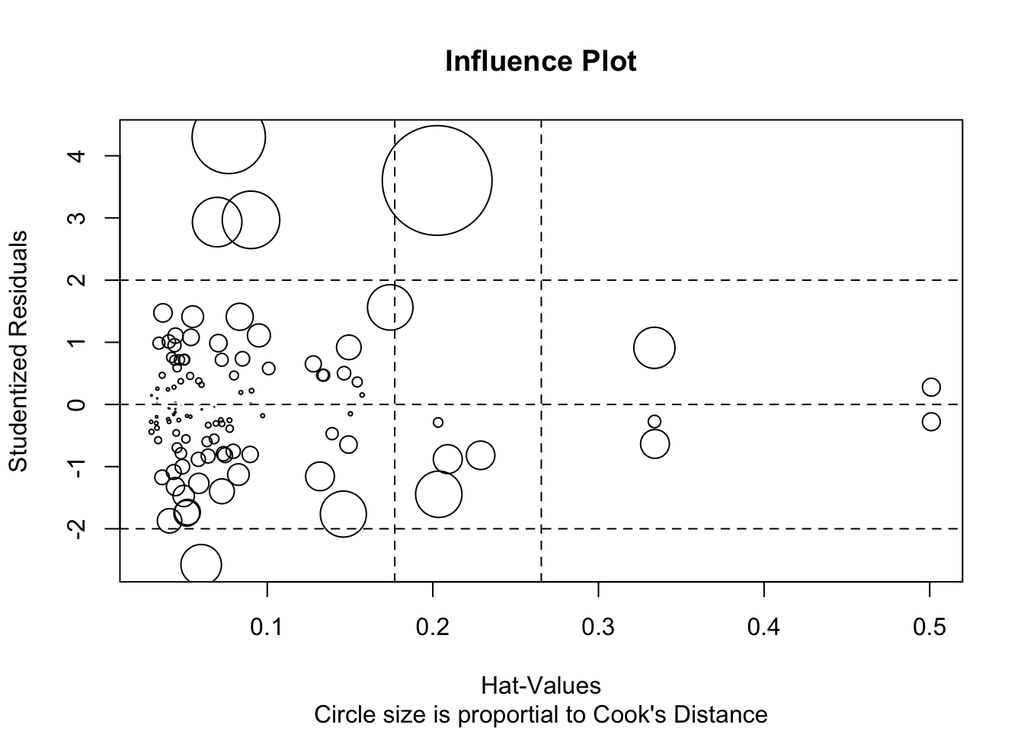

```r
influencePlot(model1,  id.method="identify", main="Influence Plot", sub="Circle size is proportial to Cook's Distance" )
```

```r
CooksD <- cooks.distance(model1)
Residuals <- stdres(model1)
infl <- cbind(apc1$id, CooksD,Residuals)
infl[CooksD > 4/51, ]
```

```
##             CooksD Residuals
## 47   47 0.13157034  3.977572
## 101 101 0.08126502  2.863034
## 112 112 0.29546830  3.410084
```

```r
leverage <- hatvalues(model1)
lev <- data.frame(apc1$id, leverage)
lev <- lev[order(-lev$leverage),]
head(lev, n=20)
```

```
##     apc1.id  leverage
## 46       46 0.5009856
## 25       25 0.5009856
## 100     100 0.3341231
## 44       44 0.3338211
## 90       90 0.3337750
## 13       13 0.2288506
## 74       74 0.2090217
## 23       23 0.2035849
## 11       11 0.2032056
## 112     112 0.2026065
## 81       81 0.1742649
## 109     109 0.1572880
## 8         8 0.1543470
## 62       62 0.1502566
## 54       54 0.1492868
## 78       78 0.1490802
## 59       59 0.1463858
## 26       26 0.1459684
## 53       53 0.1392089
## 21       21 0.1341283
```

Now that we’ve looked at the residuals and the influence statistics we see that the model fits reasonably well and meets the assumptions of regression). We can now proceed to testing hypotheses about the regression coefficients.

```r
summary(lm(formula = loglos ~ age + infrisk + medschl + region + medschl *
    region, data = apc1))
```

```
##
## Call:
## lm(formula = loglos ~ age + infrisk + medschl + region + medschl *
##     region, data = apc1)
##
## Residuals:
##      Min       1Q   Median       3Q      Max
## -0.29404 -0.06549 -0.00934  0.05586  0.46165
##
## Coefficients:
##                      Estimate Std. Error t value Pr(>|t|)
## (Intercept)          1.401266   0.150013   9.341 2.16e-15 ***
## age                  0.007265   0.002654   2.738  0.00729 **
## infrisk              0.061793   0.009232   6.693 1.17e-09 ***
## medschlYes           0.215359   0.091316   2.358  0.02024 *
## regionNE             0.273747   0.041111   6.659 1.38e-09 ***
## regionNC             0.187583   0.040411   4.642 1.02e-05 ***
## regionS              0.172525   0.038827   4.443 2.24e-05 ***
## medschlYes:regionNE -0.144034   0.109427  -1.316  0.19101
## medschlYes:regionNC -0.096081   0.105185  -0.913  0.36314
## medschlYes:regionS  -0.169111   0.118688  -1.425  0.15723
## ---
## Signif. codes:  0 '***' 0.001 '**' 0.01 '*' 0.05 '.' 0.1 ' ' 1
##
## Residual standard error: 0.1208 on 103 degrees of freedom
## Multiple R-squared:  0.5764, Adjusted R-squared:  0.5393
## F-statistic: 15.57 on 9 and 103 DF,  p-value: 9.224e-16
```

Before we interpret anything in this model, we want to run a partial F test to determine if the inclusion of the interaction terms significantly improves the fit of our model. Here we will refer to the model with the interaction term as the full model and the model without the interaction terms as the reduced model.

```r
## FULL MODEL
model1 <- lm(loglos ~ age + infrisk + medschl + region +medschl*region, data=apc1)

## REDUCED MODEL
model2 <- lm(loglos ~ age + infrisk + medschl + region, data=apc1)

## PARTIAL F-TEST
anova(model2, model1)
```

```
## Analysis of Variance Table
##
## Model 1: loglos ~ age + infrisk + medschl + region
## Model 2: loglos ~ age + infrisk + medschl + region + medschl * region
##   Res.Df    RSS Df Sum of Sq    F Pr(>F)
## 1    106 1.5383
## 2    103 1.5029  3  0.035455 0.81 0.4912
```

```r
summary(lm(formula = loglos ~ age + infrisk + medschl + region, data = apc1))
```

```
##
## Call:
## lm(formula = loglos ~ age + infrisk + medschl + region, data = apc1)
##
## Residuals:
##      Min       1Q   Median       3Q      Max
## -0.28465 -0.06615 -0.00676  0.06081  0.47124
##
## Coefficients:
##             Estimate Std. Error t value Pr(>|t|)
## (Intercept) 1.421627   0.148699   9.560 5.48e-16 ***
## age         0.007344   0.002634   2.788  0.00628 **
## infrisk     0.059337   0.009011   6.585 1.79e-09 ***
## medschlYes  0.104981   0.033154   3.166  0.00202 **
## regionNE    0.255047   0.038081   6.698 1.05e-09 ***
## regionNC    0.177065   0.037195   4.760 6.14e-06 ***
## regionS     0.152831   0.036275   4.213 5.30e-05 ***
## ---
## Signif. codes:  0 '***' 0.001 '**' 0.01 '*' 0.05 '.' 0.1 ' ' 1
##
## Residual standard error: 0.1205 on 106 degrees of freedom
## Multiple R-squared:  0.5664, Adjusted R-squared:  0.5418
## F-statistic: 23.07 on 6 and 106 DF,  p-value: < 2.2e-16
```

**Interpreting the Results from the Reduced Model**

For our purposes we’ll focus on the overall F-test first. This can be found by looking at the F-statistic in the output. For our model, we would write this like ($F(6, 106) = 23.07, p < 0.001$) and using the value for the adjusted $R^2$, we can say that our model explained 54.18% of the variance ($R^2 = 0.5418$).

The next thing to notice is the parameter section. As with the previous simple linear regression the parameters form an equation. Taking only the continuous variables into account we get the following:

$Log(LOS) = 1.42 + .007*Age + .059*infrisk$

So we can see that length of stay increases slightly with age and with an increased risk of infection. But that’s not the whole picture; we also have the categorical predictors. Adding them in we get the full equation:

$Log(LOS) = 1.42 + .007*Age + .059*infrisk + .104*(Medschl-Yes) + .255(Region-NE) + .177(Region-NC) + .153(Region-S)$

So the average log(length of stay) for patients going to a medical school-affiliated hospital (Medschol-Yes = True) increases by 0.104 log-days. If that region was in the northeast, you would add a further 0.255 log-days. Note that the 0.255 doesn’t mean 0.255 extra days. Remember we’re dealing with the log-length of stay here so the effects are actually multiplicative rather than additive, so the increase would be exp(0.255) or 1.29 times more days for hospitals in the northeast region compared to those in the west .

But what about the western region? What about non-medical school hospitals? We chose these values as the reference frames. So the actual interpretation of the other coefficients is relative. In other words, medical schools have a greater length of stay than non-medical school hospitals. People in the northeast region stay longer than those in the west. It’s not that people in the west don’t have a length of stay, the value is just part of the intercept, and all other values are relative to that reference frame.

Basically, multiple regression is similar to simple regression, just with more coefficients. The crucial difference to remember is that the questions “Is the slope for this variable zero?” and “Is this model significant?” are no longer the same question; we now have several slopes to measure. As we can see from the first model, the model can still be significant even if some of the terms aren’t. Also remember that adding a variable will always increase the predictive power of your model, but that doesn’t necessarily make the model better.